# Caso Euromotors

# 1. Planteamiento del problema

En este notebook les mostraré paso a paso el análisis del problema propuesto. El objetivo de este ejercicio es la resolución de las siguientes incógnitas:

**1. ¿Cómo son los clientes de lujo para enfocar las estrategias de marketing?**

```
- Seleccionar las 10 variables más importantes del dataset

- ¿Son los precios similares a los de la realidad?
```

**2. ¿Cómo hacer la campaña de marketing más efectiva?**

```
- Seleccionar las variables más relevantes

- ¿De qué manera confirmaría que la propuesta es la adecuada?
```

# 2. Información general

Los pasos a seguir son los siguientes:

**A) Limpieza de la data**

**B) Exploración de los datos**

**C) Construcción del modelo**

**D) Revisión de los resultados**

# 3. Planeamiento del proyecto

Cuando estoy por empezar un proyecto, me gusta poner el plan que llevaré a cabo.

*Entender la naturaleza de la data (summary(), str())*

*Histogramas y boxplots*

*Conteo de valores*

*Manipulación de valores nulos*

*Correlación entre métricas*

*Exploración de temas interesantes*

- ¿A mayores ingresos tienen más posibilidades de tener un auto de lujo?
  - Sería interesante la revisión de las tarjetas de crédito y deudas
- ¿El tipo de trabajo está relacionado con tener un auto de lujo?
- ¿Por qué tipo de medio se informan las personas con autos de lujo?
  - Hay datos sobre periódicos, internet y noticias en general
- ¿La edad y el sexo están relacionados con tener un auto de lujo?

*Feature engineering*

*Construcción del modelo*

*Test del modelo (matriz de confusión)*

# 4. Limpieza de la data

## Lectura incial de datos

Para empezar, se leen los datos del csv y se ve las dimensiones

```r
db<-read.csv("Base de datos caso práctico.csv")

#View(db)

dim(db)
```

```
[1] 5000  124
```

Son 5000 filas y 124 columnas

```r
summary(db)
```

```
    custid              region         townsize         gender            age            agecat       birthmonth
 Length:5000        Min.   :1.000   Min.   :1.000   Min.   :0.0000   Min.   :18.00   Min.   :2.000   Length:5000
 Class :character   1st Qu.:2.000   1st Qu.:1.000   1st Qu.:0.0000   1st Qu.:31.00   1st Qu.:3.000   Class :character
 Mode  :character   Median :3.000   Median :3.000   Median :1.0000   Median :47.00   Median :4.000   Mode  :character
                    Mean   :3.001   Mean   :2.687   Mean   :0.5036   Mean   :47.03   Mean   :4.239
                    3rd Qu.:4.000   3rd Qu.:4.000   3rd Qu.:1.0000   3rd Qu.:62.00   3rd Qu.:5.000
                    Max.   :5.000   Max.   :5.000   Max.   :1.0000   Max.   :79.00   Max.   :6.000
                                    NA's   :2
       ed            edcat           jobcat          union            employ          empcat          retire
 Min.   : 6.00   Min.   :1.000   Min.   :1.000   Min.   :0.0000   Min.   : 0.00   Min.   :1.000   Min.   :0.0000
 1st Qu.:12.00   1st Qu.:2.000   1st Qu.:1.000   1st Qu.:0.0000   1st Qu.: 2.00   1st Qu.:2.000   1st Qu.:0.0000
 Median :14.00   Median :2.000   Median :2.000   Median :0.0000   Median : 7.00   Median :3.000   Median :0.0000
 Mean   :14.54   Mean   :2.672   Mean   :2.753   Mean   :0.1512   Mean   : 9.73   Mean   :2.933   Mean   :0.1476
 3rd Qu.:17.00   3rd Qu.:4.000   3rd Qu.:4.000   3rd Qu.:0.0000   3rd Qu.:15.00   3rd Qu.:4.000   3rd Qu.:0.0000
 Max.   :23.00   Max.   :5.000   Max.   :6.000   Max.   :1.0000   Max.   :52.00   Max.   :5.000   Max.   :1.0000

     income            inccat         debtinc          creddebt           othdebt            default           jobsat
 Min.   :   9.00   Min.   :1.000   Min.   : 0.000   Min.   :  0.0000   Min.   :  0.0000   Min.   :0.0000   Min.   :1.000
 1st Qu.:  24.00   1st Qu.:1.000   1st Qu.: 5.100   1st Qu.:  0.3855   1st Qu.:  0.9803   1st Qu.:0.0000   1st Qu.:2.000
 Median :  38.00   Median :2.000   Median : 8.800   Median :  0.9264   Median :  2.0985   Median :0.0000   Median :3.000
 Mean   :  54.76   Mean   :2.392   Mean   : 9.954   Mean   :  1.8573   Mean   :  3.6545   Mean   :0.2342   Mean   :2.964
 3rd Qu.:  67.00   3rd Qu.:3.000   3rd Qu.:13.600   3rd Qu.:  2.0638   3rd Qu.:  4.3148   3rd Qu.:0.0000   3rd Qu.:4.000
 Max.   :1073.00   Max.   :5.000   Max.   :43.100   Max.   :109.0726   Max.   :141.4591   Max.   :1.0000   Max.   :5.000

    marital          spoused         spousedcat          reside           pets          pets_cats        pets_dogs
 Min.   :0.0000   Min.   :-1.000   Min.   :-1.0000   Min.   :1.000   Min.   : 0.000   Min.   :0.0000   Min.   :0.0000
 1st Qu.:0.0000   1st Qu.:-1.000   1st Qu.:-1.0000   1st Qu.:1.000   1st Qu.: 0.000   1st Qu.:0.0000   1st Qu.:0.0000
 Median :0.0000   Median :-1.000   Median :-1.0000   Median :2.000   Median : 2.000   Median :0.0000   Median :0.0000
 Mean   :0.4802   Mean   : 6.113   Mean   : 0.6414   Mean   :2.204   Mean   : 3.067   Mean   :0.5004   Mean   :0.3924
 3rd Qu.:1.0000   3rd Qu.:14.000   3rd Qu.: 2.0000   3rd Qu.:3.000   3rd Qu.: 5.000   3rd Qu.:1.0000   3rd Qu.:0.0000
 Max.   :1.0000   Max.   :24.000   Max.   : 5.0000   Max.   :9.000   Max.   :21.000   Max.   :6.0000   Max.   :7.0000

   pets_birds     pets_reptiles      pets_small     pets_saltfish    pets_freshfish      homeown          hometype
 Min.   :0.0000   Min.   :0.0000   Min.   :0.0000   Min.   :0.0000   Min.   : 0.000   Min.   :0.0000   Min.   :1.000
 1st Qu.:0.0000   1st Qu.:0.0000   1st Qu.:0.0000   1st Qu.:0.0000   1st Qu.: 0.000   1st Qu.:0.0000   1st Qu.:1.000
 Median :0.0000   Median :0.0000   Median :0.0000   Median :0.0000   Median : 0.000   Median :1.0000   Median :2.000
 Mean   :0.1104   Mean   :0.0556   Mean   :0.1146   Mean   :0.0466   Mean   : 1.847   Mean   :0.6296   Mean   :1.843
 3rd Qu.:0.0000   3rd Qu.:0.0000   3rd Qu.:0.0000   3rd Qu.:0.0000   3rd Qu.: 4.000   3rd Qu.:1.0000   3rd Qu.:2.000
 Max.   :5.0000   Max.   :6.0000   Max.   :7.0000   Max.   :8.0000   Max.   :16.000   Max.   :1.0000   Max.   :4.000

```

[output cut: 88 more lines]

```
     ownvcr           owndvd           owncd            ownpda          ownpc           ownipod          owngame
 Min.   :0.0000   Min.   :0.0000   Min.   :0.0000   Min.   :0.000   Min.   :0.0000   Min.   :0.0000   Min.   :0.0000
 1st Qu.:1.0000   1st Qu.:1.0000   1st Qu.:1.0000   1st Qu.:0.000   1st Qu.:0.0000   1st Qu.:0.0000   1st Qu.:0.0000
 Median :1.0000   Median :1.0000   Median :1.0000   Median :0.000   Median :1.0000   Median :0.0000   Median :0.0000
 Mean   :0.9156   Mean   :0.9136   Mean   :0.9328   Mean   :0.201   Mean   :0.6328   Mean   :0.4792   Mean   :0.4748
 3rd Qu.:1.0000   3rd Qu.:1.0000   3rd Qu.:1.0000   3rd Qu.:0.000   3rd Qu.:1.0000   3rd Qu.:1.0000   3rd Qu.:1.0000
 Max.   :1.0000   Max.   :1.0000   Max.   :1.0000   Max.   :1.000   Max.   :1.0000   Max.   :1.0000   Max.   :1.0000

     ownfax            news         response_01      response_02      response_03
 Min.   :0.0000   Min.   :0.0000   Min.   :0.0000   Min.   :0.0000   Min.   :0.0000
 1st Qu.:0.0000   1st Qu.:0.0000   1st Qu.:0.0000   1st Qu.:0.0000   1st Qu.:0.0000
 Median :0.0000   Median :0.0000   Median :0.0000   Median :0.0000   Median :0.0000
 Mean   :0.1788   Mean   :0.4726   Mean   :0.0836   Mean   :0.1298   Mean   :0.1026
 3rd Qu.:0.0000   3rd Qu.:1.0000   3rd Qu.:0.0000   3rd Qu.:0.0000   3rd Qu.:0.0000
 Max.   :1.0000   Max.   :1.0000   Max.   :1.0000   Max.   :1.0000   Max.   :1.0000
```

## Busqueda de duplicados

Se ve, por si acaso, si es que hay duplicados en el id de cliente

```r
n_occur<-data.frame(table(db$custid))
n_occur[n_occur$Freq>1,]
```

| Var1 | Freq |
| --- | --- |

No hay customers duplicados

## Cambio de variables categóricas a factor

Se cambian todas las variables categóricas a factores:

```r
db$region<-as.factor(db$region)
db$townsize<-as.factor(db$townsize)
db$gender<-as.factor(db$gender)
db$agecat<-as.factor(db$agecat)
db$edcat<-as.factor(db$edcat)
db$jobcat<-as.factor(db$jobcat)
db$union<-as.factor(db$union)
db$empcat<-as.factor(db$empcat)
db$retire<-as.factor(db$retire)
db$inccat<-as.factor(db$inccat)
db$default<-as.factor(db$default)
db$jobsat<-as.factor(db$jobsat)
db$marital<-as.factor(db$marital)
db$spousedcat<-as.factor(db$spousedcat)
db$homeown<-as.factor(db$homeown)
db$hometype<-as.factor(db$hometype)
db$addresscat<-as.factor(db$addresscat)
db$carown<-as.factor(db$carown)
db$cartype<-as.factor(db$cartype)
db$carcatvalue<-as.factor(db$carcatvalue)
db$carbought<-as.factor(db$carbought)
db$carbuy<-as.factor(db$carbuy)
db$carcatvalue<-as.factor(db$carcatvalue)
db$commute<-as.factor(db$commute)
db$commutecat<-as.factor(db$commutecat)
db$commutecar<-as.factor(db$commutecar)
db$commuterail<-as.factor(db$commuterail)
db$commutebus<-as.factor(db$commutebus)
db$commutemotorcycle<-as.factor(db$commutemotorcycle)
db$commutepublic<-as.factor(db$commutepublic)
db$commutebike<-as.factor(db$commutebike)
db$commutewalk<-as.factor(db$commutewalk)
db$commutenonmotor<-as.factor(db$commutenonmotor)
db$telecommute<-as.factor(db$telecommute)
db$reason<-as.factor(db$reason)
db$birthmonth<-as.factor(db$birthmonth)
db$polview<-as.factor(db$polview)
db$ebill<-as.factor(db$ebill)
db$polparty<-as.factor(db$polparty)
db$vote<-as.factor(db$vote)
db$card<-as.factor(db$card)
db$cardtype<-as.factor(db$cardtype)
db$cardbenefit<-as.factor(db$cardbenefit)
db$card2<-as.factor(db$card2)
db$card2type<-as.factor(db$card2type)
db$card2benefit<-as.factor(db$card2benefit)
db$active<-as.factor(db$active)
db$bfast<-as.factor(db$bfast)
db$churn<-as.factor(db$churn)
db$tollfree<-as.factor(db$tollfree)
db$equip<-as.factor(db$equip)
db$callcard<-as.factor(db$callcard)
db$wireless<-as.factor(db$wireless)
db$wiremon<-as.factor(db$wiremon)
db$multline<-as.factor(db$multline)
db$voice<-as.factor(db$voice)
db$pager<-as.factor(db$pager)
db$internet<-as.factor(db$internet)
db$callid<-as.factor(db$callid)
db$forward<-as.factor(db$forward)
db$confer<-as.factor(db$confer)
db$owntv<-as.factor(db$owntv)
db$ownvcr<-as.factor(db$ownvcr)
db$owndvd<-as.factor(db$owndvd)
db$owncd<-as.factor(db$owncd)
db$ownpda<-as.factor(db$ownpda)
db$ownpc<-as.factor(db$ownpc)
db$ownipod<-as.factor(db$ownipod)
db$owngame<-as.factor(db$owngame)
db$ownfax<-as.factor(db$ownfax)
db$news<-as.factor(db$news)
db$card2fee<-as.factor(db$card2fee)
db$response_01<-as.factor(db$response_01)
db$response_02<-as.factor(db$response_02)
db$response_03<-as.factor(db$response_03)
db$polcontrib<-as.factor(db$polcontrib)
db$cardfee<-as.factor(db$cardfee)
db$commutecarpool<-as.factor(db$commutecarpool)
db$callwait<-as.factor(db$callwait)
db$ebill<-as.factor(db$ebill)
```

## Visualización de valores nulos

Ahora veamos qué columnas tienen una alta cantidad de valores nulos

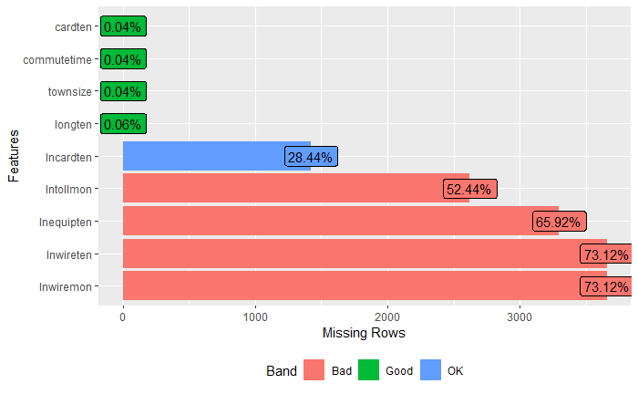

```r
plot_missing(db,missing_only = TRUE)
```

Se pasan a eliminar las columans con datos faltantes mayores al 20% (5 columnas)

```r
db<-db[, colMeans(is.na(db)) <= .2]
dim(db)
```

```
[1] 5000  119
```

A continuación podemos ver las columnas que quedan con datos faltantes

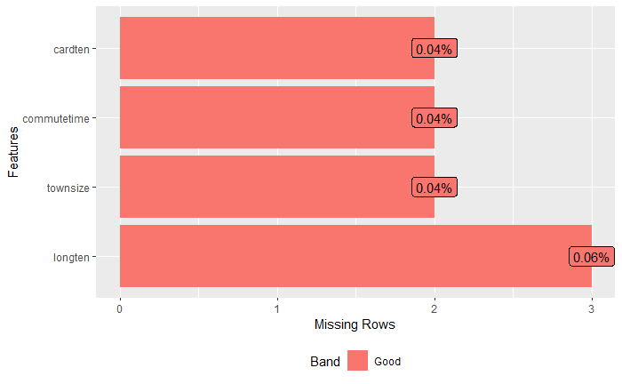

```r
plot_missing(db,missing_only = TRUE)
```

Ahora, se pasará a imputar estas columnas

```r
db<-kNN(db)
db<-db%>%select(-ends_with("_imp")) #Para eliminar las columnas adicionales que se generan en la imputación
```

Se crea una columna condicional que indica las personas que tienen un auto de lujo (carcatvalue=3)

```r
db$lujo_si<-ifelse(db$carcatvalue==3,1,0)

db$lujo_si<-as.factor(db$lujo_si)
```

Finalmente, guardamos una copia de seguridad de los datos tratados

```r
write.csv(db,"db_clean.csv")
```